# Lecture #4: Probability Spaces & Discrete Random Variables

MATH 321 – Mathematical Statistics I

Torin Quinlivan

tquinlivan@knox.edu

Knox College

September 25, 2026

## Review: Axioms of Probability

**Definition:** A probability space is a triple $(\Omega, \mathcal{F} , P)$, where $\Omega$ is the sample space, $\mathcal{F}$ is the event space, and $P$ is a probability law (or measure).

**Definition:** A probability law is a function $P : \mathcal{F} \to [0,\, 1]$ that maps an event $A$ to a real number in $[0,\, 1]$. The function must satisfy the axioms of probability:

1. **Non-Negativity:** $P(A) \ge 0$, for any $A \subseteq \Omega$.
2. **Normalization:** $P(\Omega) = 1$.
3. **Additivity:** For any disjoint sets $\{A_1,\, A_2,\, A_3,\, \dots \}$, it must be true that
   $$P \left( \bigcup_{i=1}^\infty A_i \right) = \sum_{i=1}^\infty P(A_i).$$

## Review: Important Properties and Results

**Corollary:** Let $A \in \mathcal{F}$ be an event. Then:

1. $P(\overline{A}) = 1 - P[A]$.
2. $P(A) \le 1$.
3. $P(\varnothing) = 0$.

**Corollary (Unions of Two Non-Disjoint Sets):** For any $A$ and $B$ in $\mathcal{F}$,
$$P(A \cup B) = P(A) + P(B) - P(A \cap B).$$

## Review: Important Properties and Results

**Corollary (Inequalities):** Let $A$ and $B$ be two events in $\mathcal{F}$. Then:

1. $P(A \cup B) \le P(A) + P(B)$. (Union Bound)
2. If $A \subseteq B$, then $P(A) \le P(B)$.

**Theorem (Bayes’ Theorem):** For any two events $A$ and $B$ such that $P(A) > 0$ and $P(B) > 0$,
$$P(A \,\vert\, B) = \frac{P(B \,\vert\, A) P(A)}{P(B)}.$$

## Review: Important Properties and Results

**Theorem (Law of Total Probability):** Let $\{A_1,\, A_2,\, A_3,\, \dots\}$ be a partition of $\Omega$, i.e., $A_1,\, A_2,\, A_3,\, \dots$ are disjoint and $\Omega = A_1 \cup A_2 \cup \dots$. Then, for any $B \subseteq \Omega$,
$$P(B) = \sum_{i \in I} P(B \,\vert\, A_i) P(A_i).$$

**Corollary:** Let $\{A_1,\, A_2,\, A_3,\, \dots\}$ be a partition of $\Omega$, i.e., $A_1,\, A_2,\, A_3,\, \dots$ are disjoint and $\Omega = A_1 \cup A_2 \cup \dots$. Then, for any $B \subseteq \Omega$,
$$P(A_j \,\vert\, B) = \frac{P(B \,\vert\, A_j) P(A_j)}{\sum_{i \in I} P(B \,\vert\, A_i) P(A_i)}.$$

## Prove You’re a Probability Space!

**Example:** Let $S$ be a (non-empty) set. Then $(S, \mathcal{P}(S), P)$ is a probability space, where $P(A) = \dfrac{\lvert A \rvert}{\lvert S \rvert}$ for any $A \in \mathcal{P}(S)$.

**Example:** Let $A \subset \Omega$, where $(\Omega,\, \mathcal{F} , P)$ is a probability space and $P(A) > 0$. Show $\widehat{P}(B) = \dfrac{P(B \cap A)}{P(A)}$ defines a probability measure on $\mathcal{F} \cap A$.

## Random Variables

Let $(\Omega, \mathcal{F}, P)$ be a probability space.

**Definition:** A random variable $X$ is a function $X : \Omega \to \mathbb{R}$ that maps an outcome $\xi \in \Omega$ to a number $X(\xi)$ on the real line.

**Definition:** A random variable $Y$ is said to be discrete if it can assume only a finite or countably infinite number of distinct values.

**Example:** Let $\Omega$ consist of the outcomes of tossing a (fair) coin three times and let $X : \Omega \to \mathbb{R}$ be the number of heads that appears.

## Probability Mass Functions

**Definition:** The probability mass function (PMF) of a random variable $X$ is a function which specifies the probability of obtaining a number $X(\xi) = x$. We denote a probability mass function as:
$$p_X(x) = P(X = x).$$
The set of all possible states of $X$ is denoted as $X(\Omega)$.

**Example:** Let $\Omega$ consist of the outcomes of tossing a (fair) coin three times and let $X : \Omega \to \mathbb{R}$ be the number of heads that appears. What is the probability mass function (PMF) of this random variable?

## Properties of Probability Mass Functions

Random variables have a graphical representation called a probability histogram.

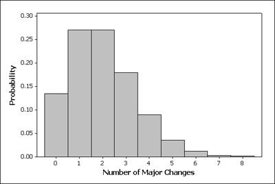

## Properties of Probability Mass Functions

**Theorem:** If $A \subset X(\Omega)$, then the function $P(A) = \displaystyle\sum_{x \in A} p_X(x)$ is a probability law of $X(\Omega)$.

Can you prove this?

## The Expected Value of a Random Variable

**Definition:** Let $X$ be a discrete random variable with the probability mass function $p_X(x)$. Then the expected value (or mean) of $X$, $E(X)$, is defined to be:
$$E(X) = \sum_x x \, p_X(x).$$
If $p_X(x)$ is an accurate characterization of the population frequency distribution,then $E(X) = \mu$, the population mean.

## The Expected Value of a Function of a Random Variable

**Definition:** Let $X$ be a discrete random variable with probability mass function $p_X(x)$ and $g(X)$ be a real-valued function of $X$. Then the expected value of $g(X)$ is given by:
$$E(g(X)) = \sum_x g(x) \, p_X(x).$$

## Moments of a Random Variable

A specific case of an expected value of a function of a random variables are the moments of the random variables.

The $n^{th}$ moment of a random variable X is defined as:
$$E(X^n) = \sum_x x^n \, p_X(x).$$

The $n^{th}$ central moment of a random variable X is defined as:
$$E((X-\mu)^n) = \sum_x (x-\mu)^n \, p_X(x),$$
where $\mu = E(X)$.

## Properties of the Expected Value

**Theorem:** Let $X$ be a discrete random variable with probability mass function $p_X(x)$ and $c$ be a constant. Then $E(c) = c$.

**Theorem:** Let $X$ be a discrete random variable with probability mass function $p_X(x)$, $g(X)$ be a function of $X$, and $c$ be a constant. Then:
$$E[c \times g(X)] = c \times E[g(X)].$$

**Theorem:** Let $X$ be a discrete random variable with probability mass function $p_X(x)$ and $g_1(X),\, g_2(X),\, \dots,\, g_k(X)$ be $k$ functions of $X$. Then:
$$E\left[\sum_{i=1}^k g_i(X)\right] = \sum_{i=1}^k E\big[g_i(X)\big].$$

## Variance of a Random Variable

$E(X)$ gives the mean of the population with distribution given by $p_X(x)$. Now let’s define the variance and standard deviation of this population.

**Definition:** The variance of a set of measurements is the average of the square of the differences between the values in a set of measurements and their mean, denoted as $\sigma^2$.

**Definition:** The standard deviation of $X$ is the positive square root of $V(X)$, denoted as $\sigma$.

## Formulas for the Variance

**Definition:** If $X$ is a random variable with mean $\mu = E(X)$, the variance of a random variable $X$ is defined to be the expected value of $(X − \mu)^2$. That is,
$$V(X) = E[(X − \mu)^2].$$

**Theorem:** Let $X$ be a discrete random variable with probability mass function $p_X(x)$ and finite mean $E(X) = \mu$; then:
$$V(X) = E[(X − \mu)^2] = E(X^2) - \big[E(X)\big]^2$$

This second formula is a lot easier to use!

## Properties of the Variance

**Theorem:** Let $X$ be a discrete random variable with probability mass function $p_X(x)$ and $c$ be a constant. Then $V(c) = 0$.

**Theorem:** Let $X$ be a discrete random variable with probability mass function $p_X(x)$ and $c$ be a constant. Then:
$$V[c \times X] = c^2 \times V[X].$$

**Theorem:** Let $X_1,\, X_2,\, X_3,\, \dots$ be discrete independent random variables with probability mass functions $p_{X_1}(x),\, p_{X_2}(x),\, p_{X_3}(x),\, \dots$. Then:
$$V\left[\sum_{i=1}^k X_i \right] = \sum_{i=1}^k V\big[ X_ i \big].$$